# RBIF102 Week 4 Homework

Rita Pecuch

2024-11-04

## Question 1

Q1: What is the sequence of the most common read in the library?

By executing the below code block, we can see that the most common read in the library of diabetic cell chromosome 22 reads is TCGCCTTAATACTTTTTTATTTTGTTTTATTTTGAA.

```r
library(ShortRead)

# Read chromosome 22 reads from diabetic cells
dia <- readFasta("/Users/ritapecuch/Downloads/dia_ch22.fasta")
dia <- sread(dia)
# Print out 10 most common reads and their frequencies
dia.tables <- tables(dia, n=10)
dia.tables$top
```

```
## TCGCCTTAATACTTTTTTATTTTGTTTTATTTTGAA GCTGCAGTTAAAAAGCTCGTAGTTGGATCTTGGGAG
##                                54754                                10111
## GCTCGTAGTTGGATCTTGGGAGCGGGCGGGCGGTCC GCATGCTACTGTCTAGAGCTTGTCTCAATGGATCTA
##                                 7202                                 6622
## TGCTGCAGTTAAAAAGCTCGTAGTTGGATCTTGGGA CCTCTGAGACCCACCTTGCTCATAAACAAAATGCCC
##                                 6615                                 6528
## CGCCTTAATACTTTTTTATTTTGTTTTATTTTGAAT ACCCCGTCTCTACTAAAAATACAAAAATTAGCTGGG
##                                 6360                                 5822
## CCCCGCATAAACAACATAAGCTTCTGACTCTTACCT GCCGATCACCTCTGAGACCCACCTTGCTCATAAACA
##                                 5480                                 5283
```

## Question 2

Q2: What base is most common in the first position of each read?

By executing the below line of code, we can see that the base that is the most common in the first position of each read is cytosine (C).

```r
# Look at base composition of reads
alphabetByCycle(dia)
```

```
##         cycle
## alphabet   [,1]   [,2]    [,3]    [,4]   [,5]   [,6]   [,7]   [,8]   [,9]
##        A 315305 150301  347400  121965 266691 512039 631225 756244 732396
##        C 818467 903110 1016587 1343889 770249 522355 378908 587047 455216
##        G 787937 706154  583484  467661 591382 733762 500289 470691 372377
##        T 422068 584212  396306  410262 715455 575449 833355 529795 783788
##        M      0      0       0       0      0      0      0      0      0
##        R      0      0       0       0      0      0      0      0      0
##        W      0      0       0       0      0      0      0      0      0
##        S      0      0       0       0      0      0      0      0      0
##        Y      0      0       0       0      0      0      0      0      0
##        K      0      0       0       0      0      0      0      0      0
##        V      0      0       0       0      0      0      0      0      0
##        H      0      0       0       0      0      0      0      0      0
##        D      0      0       0       0      0      0      0      0      0
##        B      0      0       0       0      0      0      0      0      0
##        N      0      0       0       0      0    172      0      0      0
##        -      0      0       0       0      0      0      0      0      0
##        +      0      0       0       0      0      0      0      0      0
##        .      0      0       0       0      0      0      0      0      0
##         cycle
## alphabet  [,10]  [,11]  [,12]  [,13]  [,14]   [,15]   [,16]  [,17]  [,18]
##        A 750945 661788 931048 624974 877128 1055105 1003582 994877 964676
##        C 491012 375738 464642 673254 336020  308259  360901 413239 521632
##        G 496260 525352 450360 469532 496687  545970  465754 416799 401542
##        T 605560 780893 497726 576016 633942  434441  513539 518858 455922
##        M      0      0      0      0      0       0       0      0      0
##        R      0      0      0      0      0       0       0      0      0
##        W      0      0      0      0      0       0       0      0      0
##        S      0      0      0      0      0       0       0      0      0
##        Y      0      0      0      0      0       0       0      0      0
##        K      0      0      0      0      0       0       0      0      0
##        V      0      0      0      0      0       0       0      0      0
##        H      0      0      0      0      0       0       0      0      0
##        D      0      0      0      0      0       0       0      0      0
##        B      0      0      0      0      0       0       0      0      0
##        N      0      6      1      1      0       2       1      4      5
##        -      0      0      0      0      0       0       0      0      0
##        +      0      0      0      0      0       0       0      0      0
##        .      0      0      0      0      0       0       0      0      0
```

[output cut: 65 more lines]

```
##        T     6
##        M     0
##        R     0
##        W     0
##        S     0
##        Y     0
##        K     0
##        V     0
##        H     0
##        D     0
##        B     0
##        N     0
##        -     0
##        +     0
##        .     0
```

## Question 3

Q3: What percentage of the reads from each library map one time using the –local option?

By executing the command shown in the below screenshot, we can see that 28.70% of the chromosome 22 reads from diabetic cells aligned exactly one time.

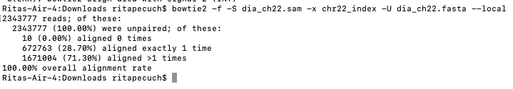

Alignment of chromosome 22 reads from diabetic cells

By executing the command shown in the below screenshot, we can see that 33.68% of the chromosome 22 reads from CRISPR corrected cells aligned exactly one time.

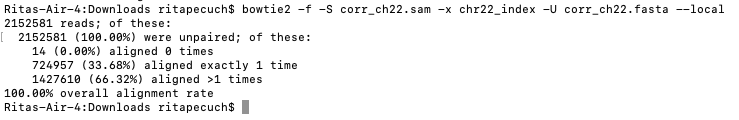

Alignment of chromosome 22 reads from CRISPR-corrected cells

## Question 4

Q4: In the region of chromosome we looked at, what genes are represented? Which is more highly expressed?

In the chr22:35,243,570-35,380,115 region, the two genes represented are TOM1 and HMGXB4.

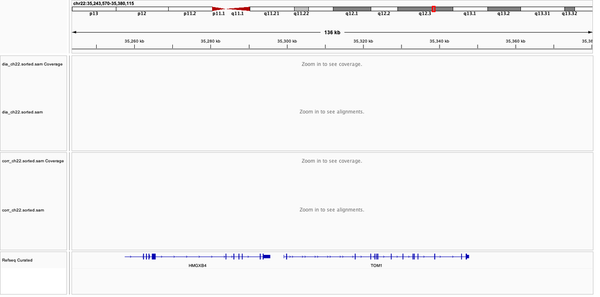

Genes represented in chr22:35,243,570-35,380,115 region

As shown in the below screenshots, a greater number of reads were mapped to the TOM1 gene, which means that it was more highly expressed than HMGXB4.

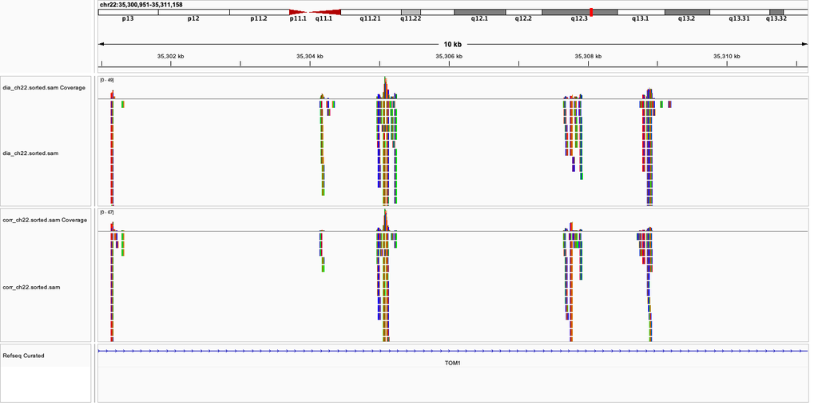

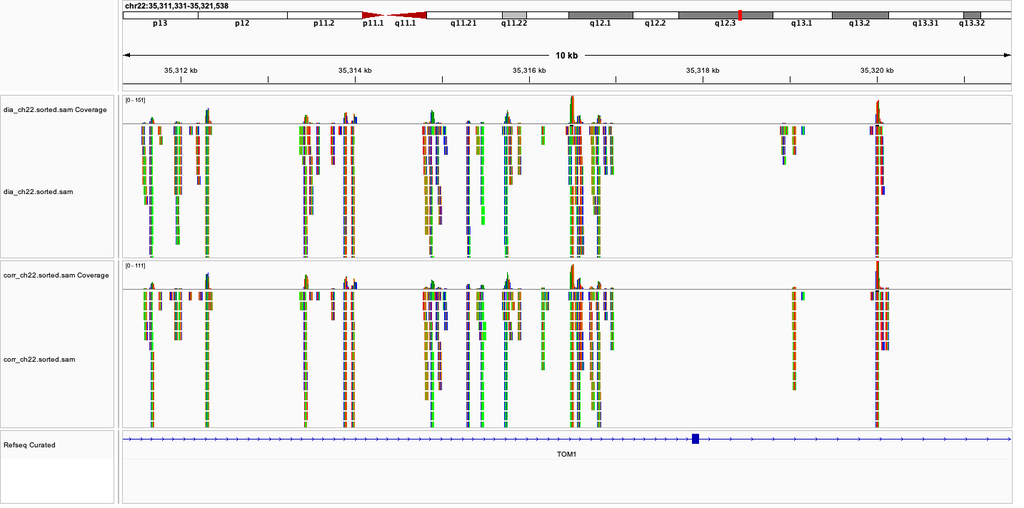

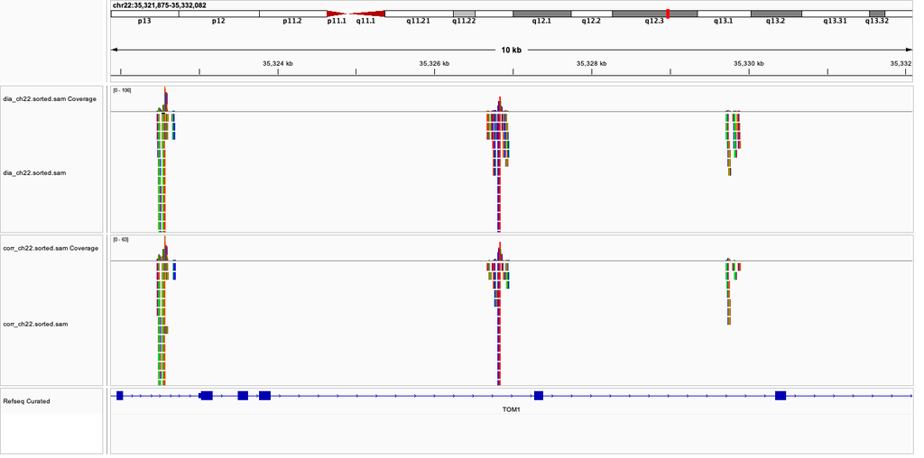

TOM1 screenshot #3

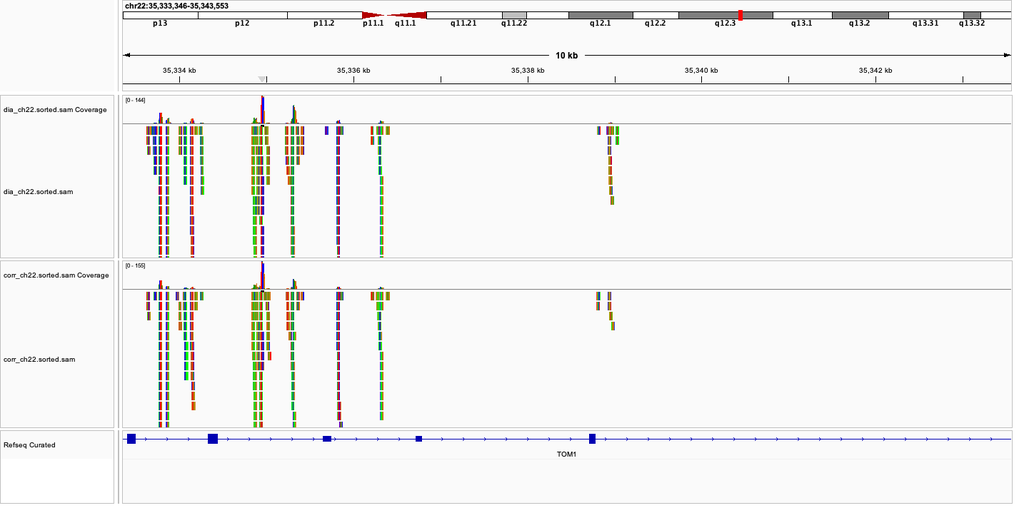

TOM1 screenshot #4

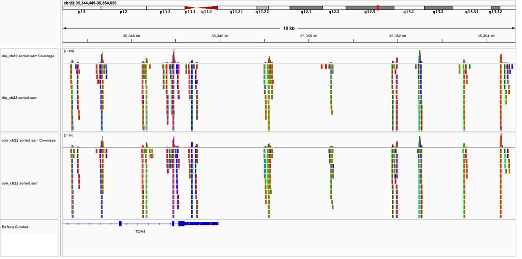

TOM1 screenshot #5

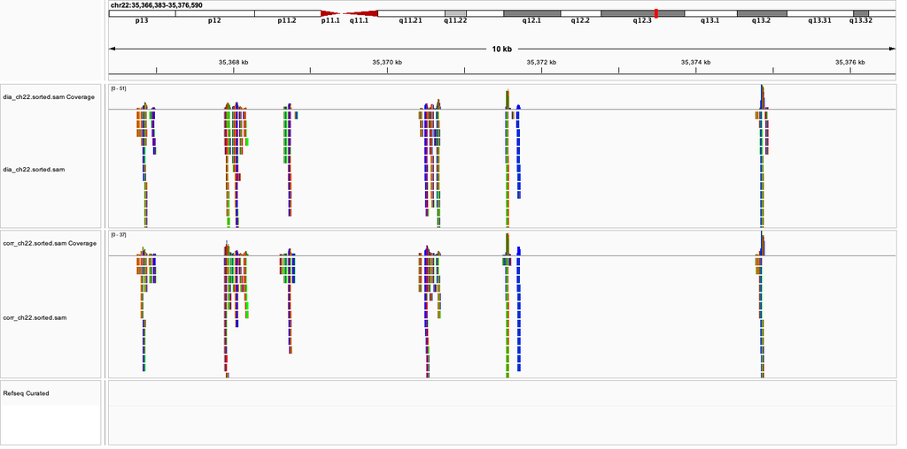

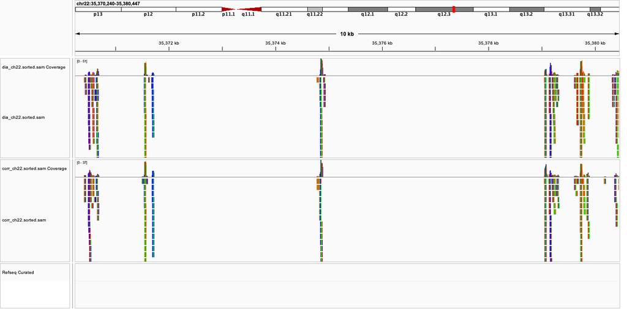

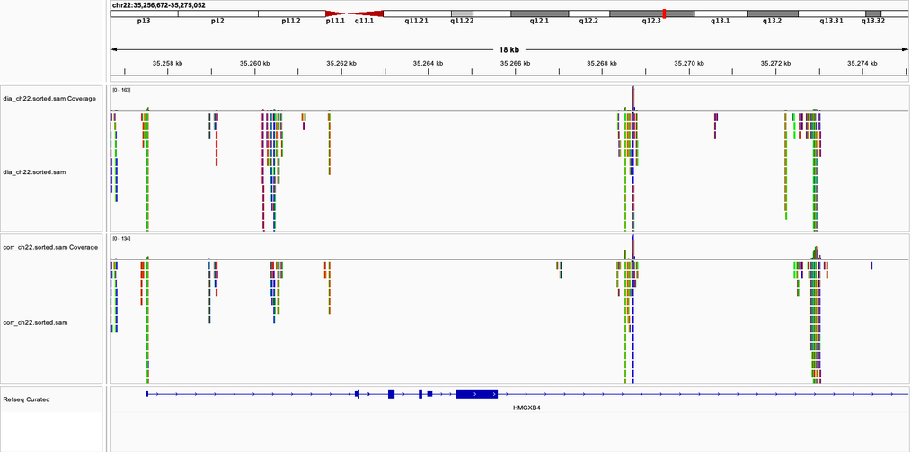

HMGXB4 screenshot #1

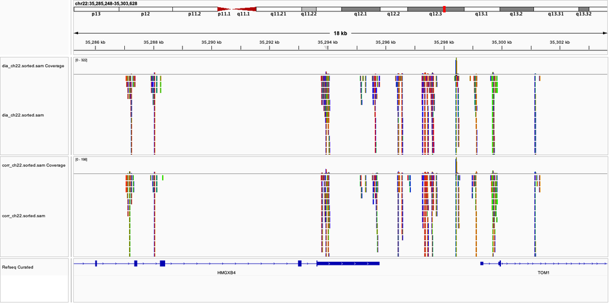

HMGXB4 screenshot #2